# Suicide Rates Analysis(1985 to 2016)

## Suicide Rates Overview 1985 to 2016

**Data Source** United Nations Development Program. (2018). Human development index (HDI). Retrieved from http://hdr.undp.org/en/indicators/137506

World Bank. (2018). World development indicators: GDP (current US$) by country:1985 to 2016. Retrieved from http://databank.worldbank.org/data/source/world-development-indicators#

[Szamil]. (2017). Suicide in the Twenty-First Century [dataset]. Retrieved from https://www.kaggle.com/szamil/suicide-in-the-twenty-first-century/notebook

World Health Organization. (2018). Suicide prevention. Retrieved from http://www.who.int/mental_health/suicide-prevention/en/

```r
data <- read_csv("master.csv")
```

## Global Trend

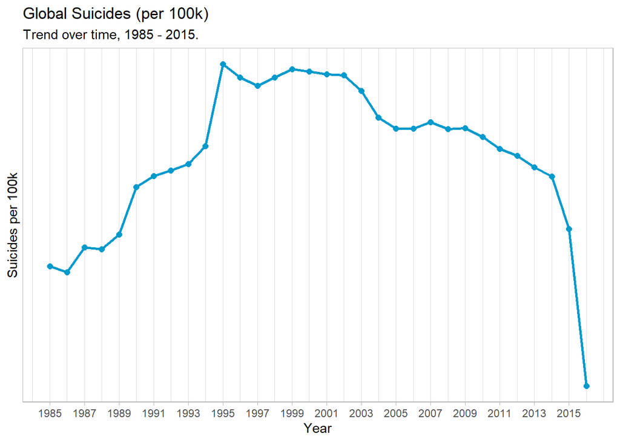

```r
#global trend
a<-data %>%
  group_by(year)%>%
  mutate(sum_year=sum(`suicides/100k pop`))

ggplot(a,aes(year,sum_year))+geom_line()+geom_point()+
  geom_line(col = "deepskyblue3", size = 1) +
  geom_point(col = "deepskyblue3", size = 2) +
  labs(title = "Global Suicides (per 100k)",
       subtitle = "Trend over time, 1985 - 2015.",
       x = "Year",
       y = "Suicides per 100k") +
  scale_x_continuous(breaks = seq(1985, 2015, 2)) +
  scale_y_continuous(breaks = seq(10, 20))
```

## Cleaning the Data

Dropped the `suicides/100k pop` & `HDI for year` variable due to in efficient labeling.Furthermore some variables labling was renamed to make it more concise.

```r
tidy_data <-  data %>%
  select(-c(`HDI for year`, `suicides/100k pop`)) %>%
  rename(gdp_for_year = `gdp_for_year ($)`,
         gdp_per_capita = `gdp_per_capita ($)`,
         country_year = `country-year`) %>%
  as.data.frame()
```

### Adding Continent

Added continent for each country in our observations via using the `countrycode` package.

```r
tidy_data$continent <- countrycode(sourcevar = tidy_data[, "country"],
                              origin = "country.name",
                              destination = "continent")
```

### Factoring the Colums

```r
tidy_data$generation <- factor(tidy_data$generation,
                          ordered = T,
                          levels = c("G.I. Generation",
                                     "Silent",
                                     "Boomers",
                                     "Generation X",
                                     "Millenials",
                                     "Generation Z"))

tidy_data <- as_tibble(tidy_data)
```

## Suicides Per 100k in Each continent

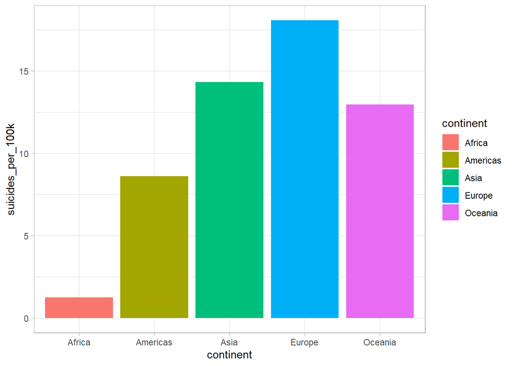

```r
b<-tidy_data %>% group_by(continent) %>%
  summarize(population = sum(population),
            suicides = sum(suicides_no),
            suicides_per_100k = (suicides / population) * 100000)

ggplot(b, aes(continent,suicides_per_100k,fill=continent))+
         geom_bar(stat = "identity")
```

**Insights** 1. Europe has the highest rate of the Suicide.

2. Africa has the lowest rate of suicide

## Suicides per 100k in between each Generation

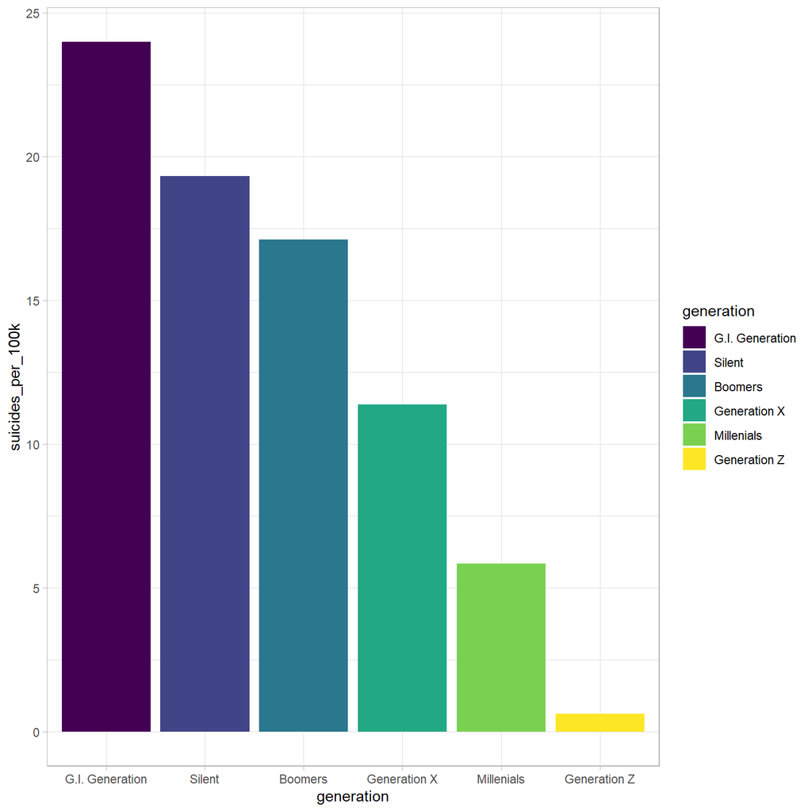

```r
tidy_data %>% group_by(generation) %>%
  summarize(
    population = sum(population),
    suicides = sum(suicides_no),
    suicides_per_100k = (suicides / population) * 100000
  ) %>%
  ggplot(aes(generation,suicides_per_100k,fill=generation))+geom_bar(stat = "identity")
```

## Suicide rates in male-female

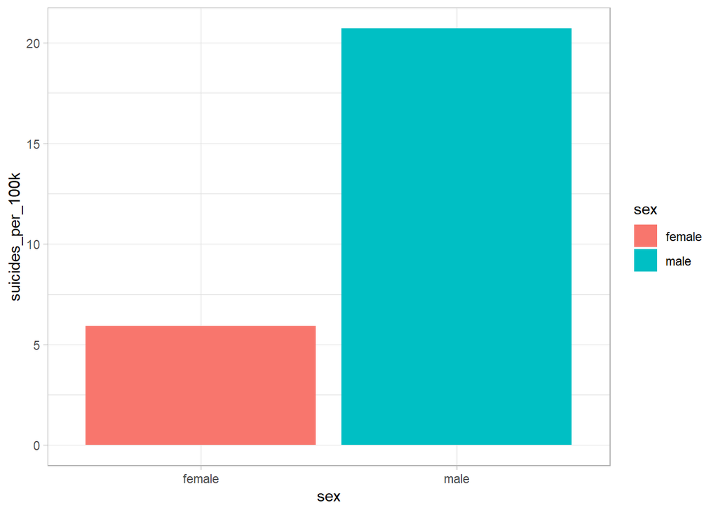

```r
tidy_data %>% group_by(sex) %>%
  summarize(
    population = sum(population),
    suicides = sum(suicides_no),
    suicides_per_100k = (suicides / population) * 100000
  ) %>%
  ggplot(aes(sex,suicides_per_100k,fill=sex))+geom_bar(stat = "identity")
```

## Trend over time, By Sex

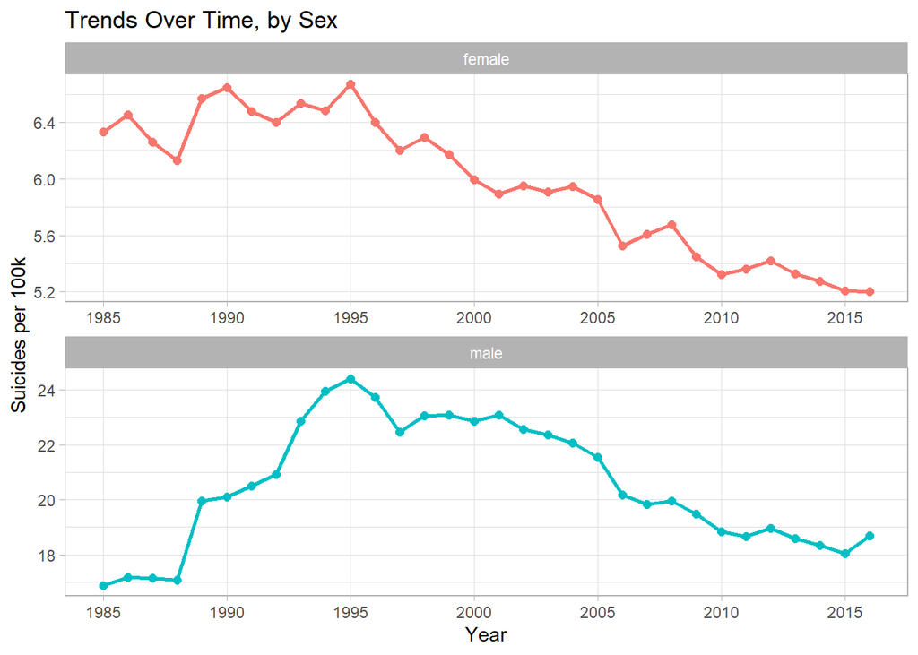

```r
trend_sex<-tidy_data %>%
  group_by(year,sex) %>%

  summarise(
    population = sum(population),
    suicides = sum(suicides_no),
    suicides_per_100k = (suicides / population) * 100000
  )

ggplot(trend_sex,aes(year,suicides_per_100k,color=sex),)+
  geom_line(size=1)+
  geom_point(size=2)+
  facet_wrap(~sex,nrow = 2,scales = 'free')+
  labs(title = "Trends Over Time, by Sex",
       x = "Year",
       y = "Suicides per 100k",
       color = "Sex") +
  theme(legend.position = "none") +
  scale_x_continuous(breaks = seq(1985, 2015, 5), minor_breaks = F)
```

## Global Suicides per 100k, by Country

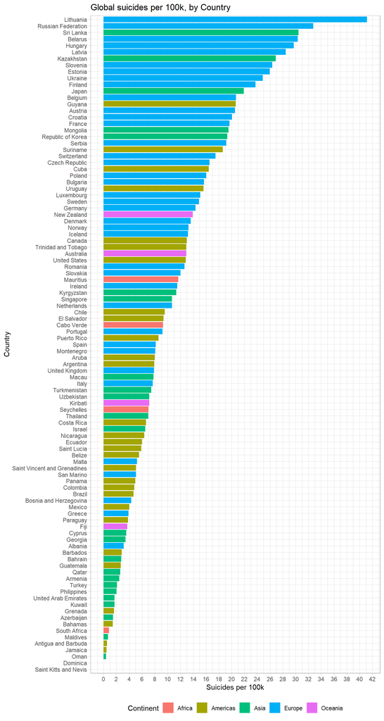

```r
country <- tidy_data %>%
  group_by(country, continent) %>%
  summarize(n = n(),
            suicide_per_100k = (sum(as.numeric(suicides_no)) / sum(as.numeric(population))) * 100000) %>%
  arrange(desc(suicide_per_100k))

country$country <- factor(country$country,
                          ordered = T,
                          levels = rev(country$country))

ggplot(country, aes(x = country, y = suicide_per_100k, fill = continent)) +
  geom_bar(stat = "identity") +

  labs(title = "Global suicides per 100k, by Country",
       x = "Country",
       y = "Suicides per 100k",
       fill = "Continent") +
  coord_flip() +
  scale_y_continuous(breaks = seq(0, 45, 2)) +
  theme(legend.position = "bottom")
```

## GDP & Suicide Rate

We see from our previous analysis that Suicide Rate in europian countries are High.So is there any corelation between a country’s GDP and suicide rate? Here each data point represents each country

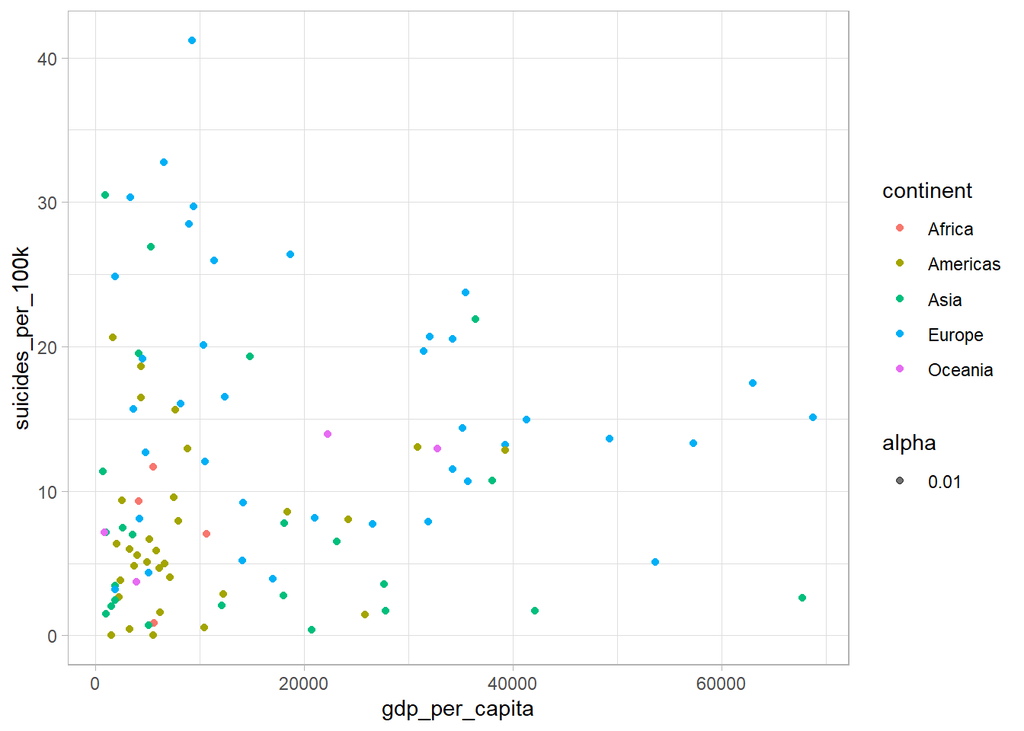

```r
gdp_suicide_rate <- tidy_data %>%
  group_by(country,continent)%>%
  summarise(
    population = sum(population),
    suicides = sum(suicides_no),
    suicides_per_100k = (suicides / population) * 100000,
    gdp_per_capita = mean(gdp_per_capita))


gdp_suicide_rate<- gdp_suicide_rate %>% ungroup() %>%
  arrange(desc(suicides_per_100k))


ggplot(gdp_suicide_rate,aes(gdp_per_capita,suicides_per_100k,color=continent))+
  geom_point(aes(alpha=0.01))+
  geom_jitter()
```

It’s Hard to see any trend with this scatter plot so we add a smooth line with `geom_smooth()`.

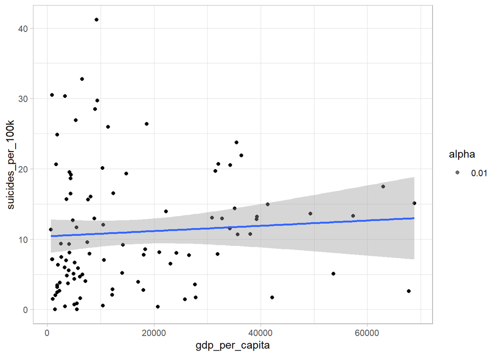

there’s a slight positive corelation between the `gdp_per_capita` & `suicides_per_100k`

## Let’s look into Asia

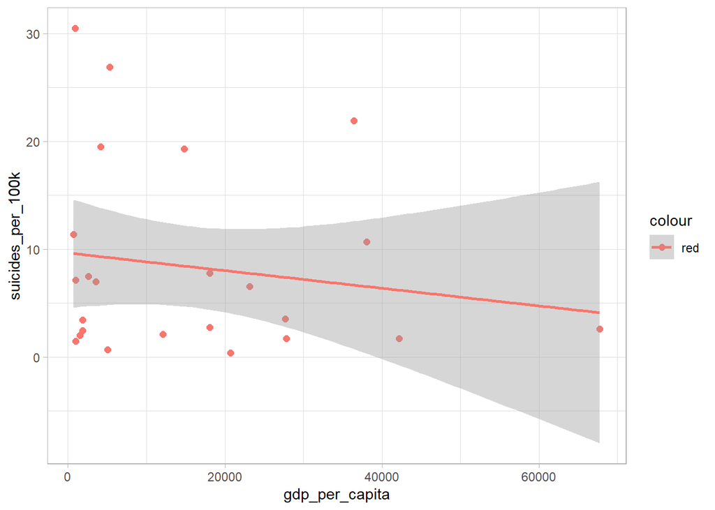

```r
gdp_suicide_rate_asia<-gdp_suicide_rate %>%
  filter(continent=="Asia")

ggplot(gdp_suicide_rate_asia,aes(gdp_per_capita,suicides_per_100k,color="red"))+
  geom_point(size=2)+
  geom_jitter() +
  geom_smooth(method = "lm")
```

Asia seems to have a negetive corelation between `gdp_per_capita` & `suicides_per_100k`